# Trend Surface

Yalin Yang

2020-04-13

## 1 Polynom Correlation

**Correlation between higher order polynoms**

### 1.1 Positive branch

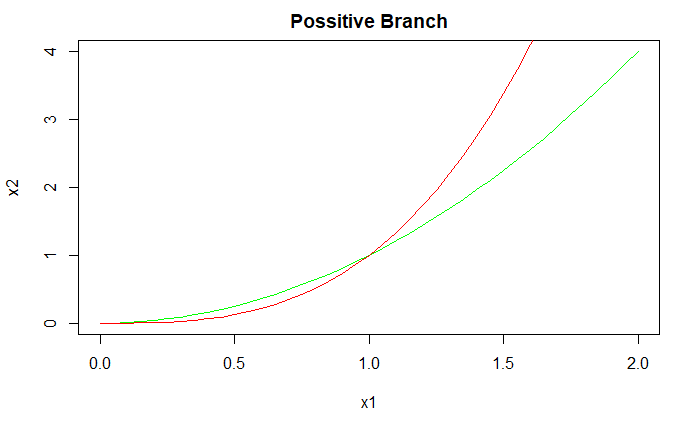

```r
x1 <- seq(0,2,by=0.05)
x2 <- x1^2
x3 <- x1^3

plot(x2~x1, type="l", col="green", main="Possitive Branch")
lines(x3~x1, col="red")
```

```r
cor(x2,x1)
```

```
[1] 0.966793
```

```r
cor(x3,x1)
```

```
[1] 0.9141454
```

### 1.2 Centered around zero

```r
x1 <- seq(-1,1,by=0.05) # note shift of scale
x2 <- x1^2
x3 <- x1^3

plot(x2~x1, type="l", ylim=range(c(x2,x3)), col="green", main="Centered around Zero")
lines(x3~x1, col="red")
```

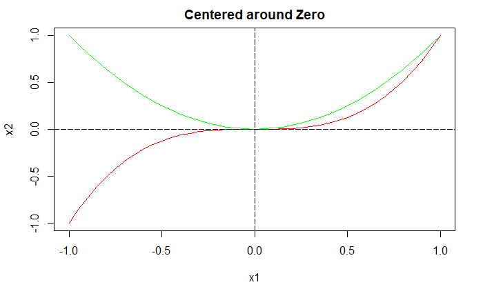

```r
abline(v=0, h=0, lty=5)
```

```r
cor(x2,x1)
```

```
[1] 1.775033e-16
```

```r
cor(x3,x1)
```

```
[1] 0.9168791
```

## Trend Surface Model

### 1.1 Transfer Coordinates to a comparable range

- Objective: z-transforms a coordinate (reduce multicollinearity among the polynomial transformed coordinates)
- `x`: vector of coordinates
- `xmean`: centers around xmean
- `xsd`: scale factor as standard deviation

| orign | transfered |
| --- | --- |
| 3.995723 | 0.3991446 |
| 7.312025 | 1.0624050 |
| 7.058019 | 1.0116038 |
| -6.812335 | -1.7624669 |
| 6.908560 | 0.9817120 |

### 1.2 Generate formula for polygonial trend-surface model

- Objective: Generate formula for polygonial trend-surface model (multiple order)
- `baseForm`: Basic formula defining the dependent variable with an intercept, i.e., `Z~1` (zero order). Or alternatively with covariables, e.g., `Z~V1+V2+I(V2^2)`(second order)
- `coordForm`: Right-hand formula defining the longitude and latitude coordinate names, i.e., ~X+Y
- `shpDf`: optional dataframe (perhaps in geo-object) to the variables names in baseForm and coordForm
- `polyDeg`: Degree of the trendsurface model (minimum is 1)

**Example: `makeTrendPolyFct(elev~rivDist, ~long+lat, kansas, polyDeg=3)`**

```r
makeTrendPolyForm <- function(baseForm=Z~1, coordForm=~X+Y, shpDf=NULL, polyDeg=1){

  ## Basic input check
  if (missing(baseForm) || class(baseForm) != "formula") stop("'baseForm' missing or incorrect")
  if (missing(coordForm) || class(coordForm) != "formula" || length(all.vars(coordForm)) != 2)
    stop("'coordForm' missing or incorrect")
  if (as.integer(polyDeg) < 1L ) stop("'polyDeg' needs to be integer of 1 or above")
  ## shpDf declare check input variables
  if (!is.null(shpDf)){
    if (class(try(model.frame(baseForm, shpDf), T)) != "data.frame") stop("Incorrect variables in 'baseFrom'")
    if (class(try(model.frame(coordForm, shpDf), T)) != "data.frame") stop("Incorrect variables in 'coordFrom'")
  }
  ## Build string with the trend-surface coordinates
  expo <- expand.grid(0L:polyDeg, 0L:polyDeg)
  expo <- expo[rowSums(expo) <= polyDeg, ]    # make sure only terms up to polyDeg enter the formula
  expo <- expo[-1,]                           # exclude x^0*y^0
  expo <- expo[order(rowSums(expo)), ]        # make sure formula is sorted by the degree of the polynomial
  formStr <- "~ ."
  xy <- all.vars(coordForm)
  for (i in 1: nrow(expo)) {
    formStr <- paste(formStr, " + I(",xy[1],"^",expo[i,1],"*",xy[2],"^",expo[i,2],")", sep="")
  }
    ## Merge covariate and polynomial formulas
  polyForm <- update(baseForm,as.formula(formStr))

  return(polyForm)
} #end::makeTrendPolyForm
```

### 1.3 Read Map Data

```r
library(maptools); library(RColorBrewer)

setwd("G:\\UTD_Classes\\2020Spring\\GISC7360_Pattern_Analysis\\Lecture05\\TrendShapeFiles")
landBnd <- rgdal::readOGR(dsn=getwd(), layer="Land", integer64="warn.loss")
proj4string(landBnd)                              # Current system
```

```
[1] "+proj=longlat +datum=WGS84 +no_defs +ellps=WGS84 +towgs84=0,0,0"
```

```r
statPts <- rgdal::readOGR(dsn=getwd(), layer="BritStations", integer64="warn.loss")
proj4string(statPts)
```

```
[1] "+proj=longlat +datum=WGS84 +no_defs +ellps=WGS84 +towgs84=0,0,0"
```

```r
elevGrid <- rgdal::readOGR(dsn=getwd(), layer="Elevation", integer64="warn.loss")
proj4string(elevGrid)
```

```
[1] "+proj=longlat +datum=WGS84 +no_defs +ellps=WGS84 +towgs84=0,0,0"
```

**read the boundary information**

```r
( boxPred <- bbox(elevGrid) )
```

```
                min      max
coords.x1 -19.28145 14.84294
coords.x2  47.72579 63.01819
```

```r
( boxCali <- bbox(statPts) )
```

```
                min       max
coords.x1 -5.433734  1.732094
coords.x2 50.219693 54.753933
```

### 1.4 Map Study Area

```r
plot(landBnd,axes=T,col=grey(0.9),border="green",
     xlim=boxPred[1,],ylim=boxPred[2,])
plot(statPts,col="red",add=T)
```

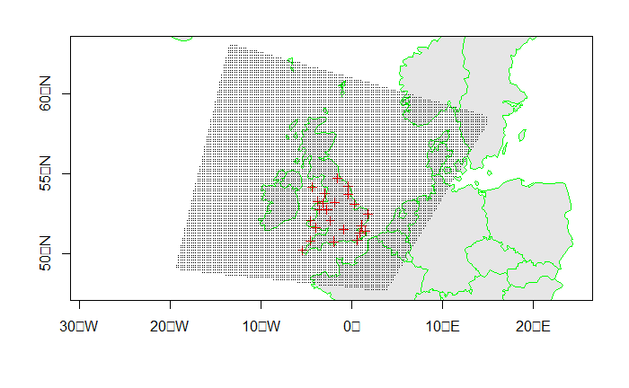

```r
plot(elevGrid,col="black",pch=".",add=T)
box()
```

**Transform coordinates**

```r
yMean <- mean(statPts$LATITUDE1); xMean <- mean(statPts$LONGITUDE1)
ySd <- sd(statPts$LATITUDE1); xSd <- sd(statPts$LONGITUDE1)
```

#### 1.4.1 Test no transformation

```r
statPts$caliX <- statPts$LONGITUDE1
statPts$caliY <- statPts$LATITUDE1
elevGrid$caliX <- elevGrid$LONGITUDE1
elevGrid$caliY <- elevGrid$LATITUDE1
```

**1st Order Trendsurface**

```r
polyForm1 <- makeTrendPolyForm(SEPTTEMP~ALT, coordForm =~caliX+caliY, shpDf=statPts, polyDeg=1)
polyForm1
```

```
SEPTTEMP ~ ALT + I(caliX^1 * caliY^0) + I(caliX^0 * caliY^1)
```

```r
lmTrend1 <- lm(polyForm1, data=statPts)
summary(lmTrend1)
```

```
Call:
lm(formula = polyForm1, data = statPts)

Residuals:
     Min       1Q   Median       3Q      Max
-1.39228 -0.39932 -0.04504  0.54466  0.93898

Coefficients:
                       Estimate Std. Error t value Pr(>|t|)
(Intercept)           4.249e+01  5.780e+00   7.352 5.74e-07 ***
ALT                  -6.409e-03  1.663e-03  -3.853 0.001072 **
I(caliX^1 * caliY^0)  3.449e-07  6.529e-08   5.282 4.25e-05 ***
I(caliX^0 * caliY^1) -4.400e-07  1.106e-07  -3.980 0.000802 ***
---
Signif. codes:  0 ‘***’ 0.001 ‘**’ 0.01 ‘*’ 0.05 ‘.’ 0.1 ‘ ’ 1

Residual standard error: 0.6339 on 19 degrees of freedom
Multiple R-squared:  0.8225,    Adjusted R-squared:  0.7945
F-statistic: 29.34 on 3 and 19 DF,  p-value: 2.441e-07
```

**2nd Order TrendSurface**

```r
polyForm2 <- makeTrendPolyForm(SEPTTEMP~ALT, ~caliX+caliY, shpDf=statPts, polyDeg=2)
lmTrend2 <- lm(polyForm2, data=statPts)
summary(lmTrend2)
```

```
Call:
lm(formula = polyForm2, data = statPts)

Residuals:
     Min       1Q   Median       3Q      Max
-0.76126 -0.36901  0.05061  0.29898  0.71271

Coefficients:
                       Estimate Std. Error t value Pr(>|t|)
(Intercept)           7.304e+00  2.079e+02   0.035 0.972412
ALT                  -6.737e-03  1.334e-03  -5.050 0.000118 ***
I(caliX^1 * caliY^0) -4.034e-06  2.352e-06  -1.715 0.105662
I(caliX^0 * caliY^1)  9.015e-07  7.891e-06   0.114 0.910459
I(caliX^2 * caliY^0) -1.123e-13  2.982e-14  -3.765 0.001695 **
I(caliX^1 * caliY^1)  7.686e-14  4.504e-14   1.707 0.107231
I(caliX^0 * caliY^2) -1.268e-14  7.483e-14  -0.169 0.867577
---
Signif. codes:  0 ‘***’ 0.001 ‘**’ 0.01 ‘*’ 0.05 ‘.’ 0.1 ‘ ’ 1

Residual standard error: 0.4879 on 16 degrees of freedom
Multiple R-squared:  0.9114,    Adjusted R-squared:  0.8782
F-statistic: 27.45 on 6 and 16 DF,  p-value: 1.445e-07
```

**Perform partial F-test: Compare first and second order trendsurface**

```r
anova(lmTrend1, lmTrend2)
```

```
Analysis of Variance Table

Model 1: SEPTTEMP ~ ALT + I(caliX^1 * caliY^0) + I(caliX^0 * caliY^1)
Model 2: SEPTTEMP ~ ALT + I(caliX^1 * caliY^0) + I(caliX^0 * caliY^1) +
    I(caliX^2 * caliY^0) + I(caliX^1 * caliY^1) + I(caliX^0 *
    caliY^2)
  Res.Df    RSS Df Sum of Sq      F   Pr(>F)
1     19 7.6343
2     16 3.8085  3    3.8259 5.3577 0.009544 **
---
Signif. codes:  0 ‘***’ 0.001 ‘**’ 0.01 ‘*’ 0.05 ‘.’ 0.1 ‘ ’ 1
```

**3rd Order TrendSurface**

```r
polyForm3 <- makeTrendPolyForm(SEPTTEMP~ALT, ~caliX+caliY, shpDf=statPts, polyDeg=3)
lmTrend3 <- lm(polyForm3, data=statPts)
summary(lmTrend3)
```

```
Call:
lm(formula = polyForm3, data = statPts)

Residuals:
     Min       1Q   Median       3Q      Max
-0.77454 -0.26530  0.08197  0.23908  0.63405

Coefficients:
                       Estimate Std. Error t value Pr(>|t|)
(Intercept)          -7.989e+03  1.087e+04  -0.735 0.476425
ALT                  -7.397e-03  1.482e-03  -4.990 0.000315 ***
I(caliX^1 * caliY^0) -5.424e-05  1.501e-04  -0.361 0.724053
I(caliX^0 * caliY^1)  4.520e-04  6.161e-04   0.734 0.477238
I(caliX^2 * caliY^0)  2.631e-12  1.750e-12   1.503 0.158591
I(caliX^1 * caliY^1)  2.196e-12  5.737e-12   0.383 0.708634
I(caliX^0 * caliY^2) -8.492e-12  1.164e-11  -0.730 0.479656
I(caliX^3 * caliY^0)  1.070e-20  2.060e-20   0.520 0.612751
I(caliX^2 * caliY^1) -5.191e-20  3.348e-20  -1.550 0.146988
I(caliX^1 * caliY^2) -2.218e-20  5.488e-20  -0.404 0.693165
I(caliX^0 * caliY^3)  5.310e-20  7.329e-20   0.725 0.482643
---
Signif. codes:  0 ‘***’ 0.001 ‘**’ 0.01 ‘*’ 0.05 ‘.’ 0.1 ‘ ’ 1

Residual standard error: 0.5017 on 12 degrees of freedom
Multiple R-squared:  0.9298,    Adjusted R-squared:  0.8713
F-statistic: 15.89 on 10 and 12 DF,  p-value: 1.966e-05
```

**check multicollinearity**

```r
car::vif(lmTrend3)
```

```
                 ALT I(caliX^1 * caliY^0) I(caliX^0 * caliY^1) I(caliX^2 * caliY^0) I(caliX^1 * caliY^1) I(caliX^0 * caliY^2) I(caliX^3 * caliY^0)
        1.491392e+00         9.368214e+06         5.278137e+07         1.902561e+04         3.697921e+07         2.074897e+08         6.902400e+01
I(caliX^2 * caliY^1) I(caliX^1 * caliY^2) I(caliX^0 * caliY^3)
        1.846586e+04         9.169283e+06         5.100711e+07
```

**Perform partial F-test: Compare second and third order trendsurface**

```r
anova(lmTrend2, lmTrend3)
```

```
Analysis of Variance Table

Model 1: SEPTTEMP ~ ALT + I(caliX^1 * caliY^0) + I(caliX^0 * caliY^1) +
    I(caliX^2 * caliY^0) + I(caliX^1 * caliY^1) + I(caliX^0 *
    caliY^2)
Model 2: SEPTTEMP ~ ALT + I(caliX^1 * caliY^0) + I(caliX^0 * caliY^1) +
    I(caliX^2 * caliY^0) + I(caliX^1 * caliY^1) + I(caliX^0 *
    caliY^2) + I(caliX^3 * caliY^0) + I(caliX^2 * caliY^1) +
    I(caliX^1 * caliY^2) + I(caliX^0 * caliY^3)
  Res.Df    RSS Df Sum of Sq      F Pr(>F)
1     16 3.8085
2     12 3.0201  4   0.78842 0.7832 0.5575
```

**Best model is 2nd order**

### 1.5 Map 2nd Order(best model) Trend Surface

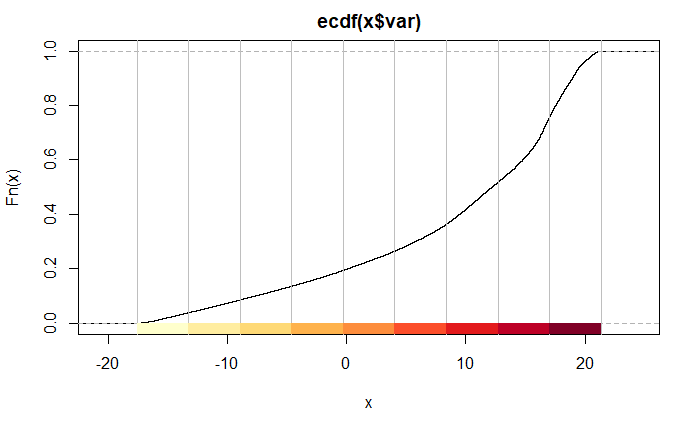

```r
## Perform Prediction
predTrend2 <- predict(lmTrend2, elevGrid, se.fit = TRUE)
predFit <- predTrend2$fit

n.col <- 9 # number of color
pal <- brewer.pal(n.col,"YlOrRd")
predClass <- classInt::classIntervals(predFit, n.col, style="equal")
plot(predClass, pal=pal)
```

**Map**

```r
predCol <- classInt::findColours(predClass,pal)

plot(elevGrid,axes=T,col=predCol,pch=15,cex=2,
     xlim=boxPred[1,],ylim=boxPred[2,],
     main="Predition: 2nd Order Trendsurface")
plot(landBnd,axes=T,border="grey50",add=T)
```

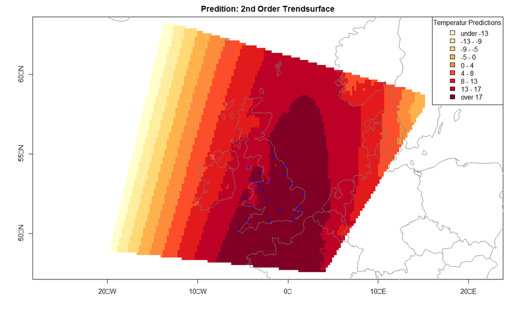

```r
plot(statPts,col="blue",add=T)
legend("topright", title = "Temperatur Predictions",
       legend = leglabs(round(predClass$brks, digits = 0)), fill = pal,
       bty = "o", ncol = 1)
```

### 1.6 Map 2nd Prediction Uncertainty

** Cannot map residuals because the prediction grid does not have observed temperature data (not all area have observed value)

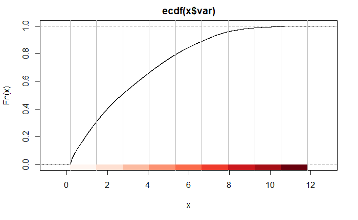

```r
predSe <- predTrend2$se
n.col <- 9
pal <- brewer.pal(n.col,"Reds")
seClass <- classInt::classIntervals(predSe, n.col, style="equal")
plot(seClass,pal=pal)
```

```r
seCol <- classInt::findColours(seClass,pal)
```

```r
plot(elevGrid,axes=T,col=seCol,pch=15,cex=2,
     xlim=boxPred[1,],ylim=boxPred[2,],
     main="Standard Error: 2nd Order Trendsurface")
plot(landBnd,axes=T,border="green",add=T)
```

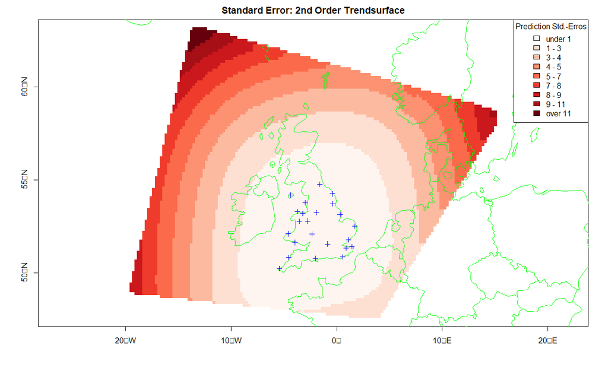

```r
plot(statPts,col="blue",add=T)
legend("topright", title = "Prediction Std.-Erros",
       legend = leglabs(round(seClass$brks, digits = 0)), fill = pal,
       bty = "o", ncol = 1)
```